# Presentación sobre Suicidio

## Introducción

Esta presentación resume los principales hallazgos del proyecto sobre las tasas de suicidio en diferentes países, con un enfoque en los objetivos marcados.

## Objetivos

1. Identificar las tendencias temporales de las tasas de suicidio en diferentes países.
2. Analizar la variación de las tasas de suicidio entre diferentes grupos de edad y género.
3. Detectar picos y caídas en las tasas de suicidio y su correlación con eventos específicos.
4. Explorar las correlaciones significativas entre las tasas de suicidio de diferentes grupos de edad y género.
5. Identificar valores atípicos en las tasas de suicidio y los países y años asociados.

## Tabla Resumen de Indicadores

Tabla Resumen de Indicadores por Categoría de Año

| year_category | Total_Suicides | Average_Suicides | Median_Suicides |
| --- | --- | --- | --- |
| 1955 a 1969 | 1022.1854 | 11.35762 | 10.10235 |
| 1970 a 1984 | 1031.7187 | 11.59234 | 12.47370 |
| 1985 a 1999 | 1035.4818 | 11.50535 | 11.55060 |
| 2000 a 2015 | 814.8086 | 10.72117 | 10.06205 |

## Gráfico de Resultados Principales

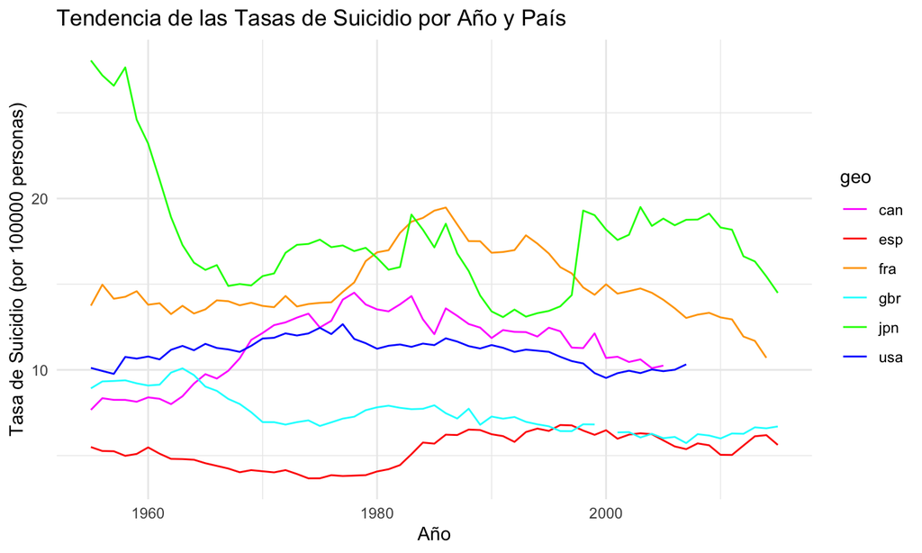

## Explicación de Resultados

### Tendencias Temporales

Los gráficos de línea muestran que algunos países como Estados Unidos y Japón tienen tendencias fluctuantes, mientras que países como Francia y Canadá muestran una tendencia decreciente después de picos iniciales.

### Picos y Caídas

Algunos países muestran picos específicos en ciertos años, lo cual podría estar relacionado con eventos socioeconómicos o políticas implementadas en esos periodos.